# DC from PDF files in R

### Introduction

PDF files are great for multiple reasons like sharing your work with others, printing in different OS etc but they are very difficult to manage when it comes to extracting data from PDFs.

Sometimes it takes a significant amount of our time for just manually copying data from PDF files to Excel or text files. In this article, I will discuss two R packages:

- [pdftools](https://cran.r-project.org/web/packages/pdftools/index.html) and
- tabulizer

for extracting data from pdf files to R work space.

The `pdftools` package is based on ‘libpoppler’ for extracting text, fonts, attachments and metadata from a PDF file.

Also it supports high quality rendering of PDF documents info PNG, JPEG, TIFF format, or into raw bitmap vectors for further processing in R.

The `tabulizer` package provides R bindings to the [Tabula](http://tabula.technology/) java library, which can be used to computationally extract tables from PDF documents.

Note that tabulizer package uses Tabula java library, so you need prior installation of 64bit Java in your computer. If you don’t have Java installed in your computer, then you should download Java setup file from this [link](https://java.com/en/download/manual.jsp) (Windows Offline (64-bit) setup file) and install Java before installing tabulizer package.

```r
suppressPackageStartupMessages({
# Install pdftools package
if (!require(pdftools)) {install.packages("pdftools")}; library(pdftools)
if (!require(devtools)) {install.packages("devtools")}; library(devtools)
if (!require(tabulizer)) {install.packages("tabulizer")}; library(tabulizer)
# Install tabulizer from github
if (!require(webp)) {install.packages("webp")}; library(webp)

   })

# first set your working directory
mywd = 'D:/current work/DC batch 11 CBA/DC/Lec 5/'
# setwd(mywd)
# getwd()    # check wd
```

### Working with pdf files in R

In this article I’ wi’ll use Alphabet’s Form 10-K compliance filing, downloadable from this [link](https://abc.xyz/investor/pdf/20161231_alphabet_10K.pdf)

Plan is to extract all the text from this 98 page pdf page by page. Say hello to the `pdf_text()` function form pdftools package.

Below, we define the PDF’s local location. Then use the `pdf_text` function to convert it to text format. Finally, print the first thousand characters from the 6th page of the pdf, using base R’s `substr()` func.

```r
# now use relative paths - good practice!
pdf_file = paste0(mywd, './20161231_alphabet_10K.pdf')
class(pdf_file)    # character
```

```
## [1] "character"
```

```r
system.time({ txt <- pdf_text(pdf_file) })    # 0.58 secs
```

```
##    user  system elapsed
##    0.36    0.00    0.36
```

```r
# First 1000 characters from Page 6 of text
cat(substr(txt[6], 1, 1000))
```

```
##  Table of Contents                                                                                             Alphabet Inc.
## PART I
##  ITEM 1.       BUSINESS
## Overview
##        As our founders Larry and Sergey wrote in the original founders' letter, "Google is not a conventional company.
## We do not intend to become one." That unconventional spirit has been a driving force throughout our history -- inspiring
## us to do things like rethink the mobile device ecosystem with Android and map the world with Google Maps. As part
## of that, our founders also explained that you could expect us to make "smaller bets in areas that might seem very
## speculative or even strange when compared to our current businesses." From the start, the company has always
## strived to do more, and to do important and meaningful things with the resources we have.
##        Alphabet is a collection of businesses -- the largest of which, of course, is Google. It also includes businesses
## that are generally pretty far afield
```

We can use `pdf_toc()` function to extract table of contents of the PDF file.

```r
# Table of contents
# setwd(mywd)
toc <- pdf_toc(pdf_file)

# Show as JSON
jsonlite::toJSON(toc, auto_unbox = TRUE, pretty = TRUE)
```

```
## {
##   "title": "",
##   "children": [
##     {
##       "title": "Cover",
##       "children": []
##     },
##     {
##       "title": "Table of Contents",
##       "children": []
##     },
##     {
##       "title": "Note About Forward-Looking Statements",
##       "children": []
##     },
##     {
##       "title": "Part I",
##       "children": [
##         {
##           "title": "Business",
##           "children": []
##         },
##         {
##           "title": "Risk Factors",
##           "children": []
##         },
##         {
##           "title": "Unresolved Staff Comments",
##           "children": []
##         },
##         {
##           "title": "Properties",
##           "children": []
##         },
##         {
##           "title": "Legal Proceedings",
##           "children": []
##         },
##         {
##           "title": "Mine Safety Disclosures",
```

[output cut: 267 more lines]

```
##     },
##     {
##       "title": "Exhibit 31.01",
##       "children": []
##     },
##     {
##       "title": "Exhibit 31.02",
##       "children": []
##     },
##     {
##       "title": "Exhibit 32.01",
##       "children": []
##     }
##   ]
## }
```

Also we can use `pdf_info()` function to extract meta data associated with the PDF file.

```r
# setwd(mywd)
# Author, version, etc, Metadata Extraction
info <- pdf_info(pdf_file)
info
```

```
## $version
## [1] "1.5"
##
## $pages
## [1] 98
##
## $encrypted
## [1] FALSE
##
## $linearized
## [1] FALSE
##
## $keys
## $keys$Producer
## [1] "WebFilings"
##
## $keys$Title
## [1] "GOOG Q4 2016 10-K"
##
##
## $created
## [1] "2017-02-23 10:35:00 IST"
##
## $modified
## [1] "2106-02-07 11:58:15 IST"
##
## $metadata
## [1] ""
##
## $locked
## [1] FALSE
##
## $attachments
## [1] FALSE
##
## $layout
## [1] "one_column"
```

### Saving as Images

The wonders continue.

Say we wanna render of PDF files as bitmap arrays. Say hello to the `pdf_render_page()` function, to render a page of the PDF into a bitmap, which can be stored as e.g. png or jpeg.

```r
# setwd(mywd)
# renders pdf to bitmap array
bitmap <- pdf_render_page(pdf_file, page = 6)

# save bitmap image, will write to wd
png::writePNG(bitmap, "page6.png")
jpeg::writeJPEG(bitmap, "page6.jpeg", quality = 5)
webp::write_webp(bitmap, "page6.webp")
```

Lets see the page6.jpeg file.

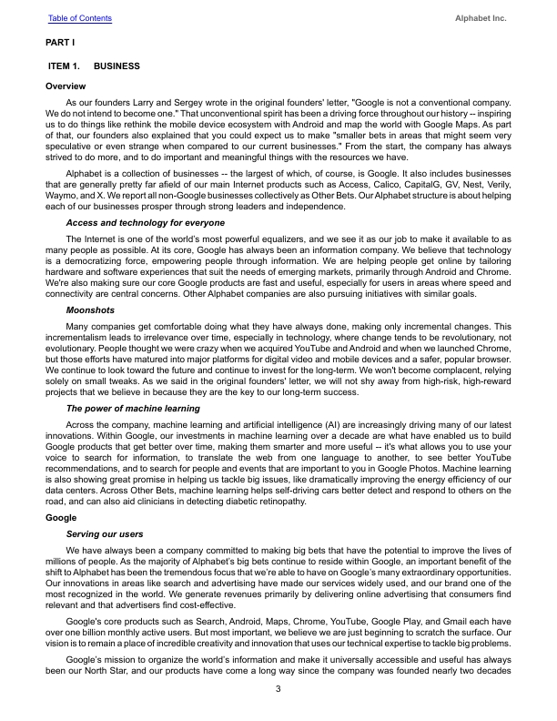

### Extracting Tables

Extracting tables from PDF files is challenging. However we can use tabulizer package for extracting nicely structured tables from the pdf. We can use tabulizer’s `extract_tables()` to extract all the tables.

Sample code and output is shown below for the Google’s 10-K.

```r
# setwd(mywd)

system.time({
tbls <- extract_tables(pdf_file)  })
```

```
##    user  system elapsed
##   66.85    0.92   39.87
```

```r
length(tbls)
```

```
## [1] 44
```

```r
str(tbls[1:5])
```

```
## List of 5
##  $ : chr [1:25, 1:2] "Note About Forward-Looking Statements" "PART I" "Item 1. Business" "Item 1A. Risk Factors" ...
##  $ : chr [1:8, 1:2] "â\200¢" "" "" "" ...
##  $ : chr [1:9, 1:2] "â\200¢" "" "â\200¢" "" ...
##  $ : chr [1:38, 1:9] "" "" "Consolidated Statements of Income Data:" "Revenues" ...
##  $ : chr [1:10, 1:7] "" "Google segment" "Google properties" "Google Network Members' properties" ...
```

```r
class(tbls[5][[1]])
```

```
## [1] "matrix"
```

```r
data.frame(tbls[5][[1]])
```

| X1 | X2 | X3 | X4 | X5 | X6 | X7 |
| --- | --- | --- | --- | --- | --- | --- |
|  |  | 2014 |  | 2015 |  | 2016 |
| Google segment |  |  |  |  |  |  |
| Google properties | $ | 45,085 | $ | 52,357 | $ | 63,785 |
| Google Network Members' properties |  | 14,539 |  | 15,033 |  | 15,598 |
| Google advertising revenues |  | 59,624 |  | 67,390 |  | 79,383 |
| Google other revenues |  | 6,050 |  | 7,154 |  | 10,080 |
| Google segment revenues | $ | 65,674 | $ | 74,544 | $ | 89,463 |
| Other Bets |  |  |  |  |  |  |
| Other Bets revenues | $ | 327 | $ | 445 | $ | 809 |
| Consolidated revenues | $ | 66,001 | $ | 74,989 | $ | 90,272 |

Enough gyan for now.

Sudhir